# Lab01 AD1

# Checkpoint 1

# Importando os dados

Os dados foram coletados pelo imdb, contendo nomes de séries rating entre outros.

No codigo abaixo o csv contendo os dados das séries é importado.

```r
data_all_shows <- read.csv(file="./series_from_imdb.csv", header=TRUE, sep=",")
```

# 1. Escolha um subconjunto de séries para usar nesse problema

Dentro do conjunto de dados, são seleciaonadas 3 séries.

```r
data_sub <- filter(data_all_shows, series_name %in% c("13 Reasons Why", "How to Get Away with Murder","Sherlock"))
```

# 2. Respondendo perguntas sobre as séries.

## a. Qual das séries que você escolheu é mais bem avaliada no IMDB? A diferença é grande? Pequena?

Para vermos a diferença de avaliação de cada série podemos calcular a mediana das avaliações em cada episodio da série e comparar las.

Para **13 Reasons Why** temos que a mediana é:

```r
median_reasons_why <- median(filter(data_sub, series_name == "13 Reasons Why")$UserRating)
median_reasons_why
```

```
[1] 8.5
```

Para **How to Get Away with Murder** temos que a mediana é:

```r
median_HtGAwM <- median(filter(data_sub, series_name == "How to Get Away with Murder")$UserRating)
median_HtGAwM
```

```
[1] 8.7
```

Para **Sherlock** temos que a mediana é:

```r
median_sherlock <- median(filter(data_sub, series_name == "Sherlock")$UserRating)
median_sherlock
```

```
[1] 9
```

Comparando as 3 medianas, temos que **Sherlock** é a série melhor avaliada com uma pequena diferença de *0.5* para série que tem a pior avaliação dentre as séries selecionadas.

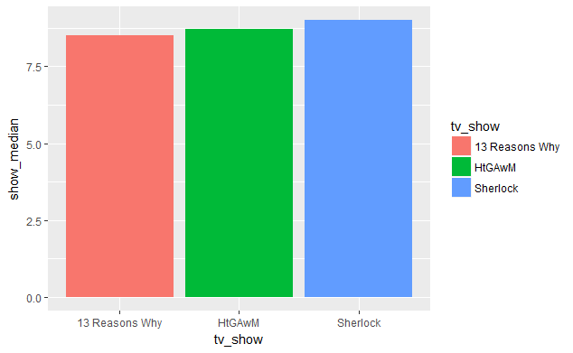

## b. Qual das séries que você escolheu tem episódios de qualidade mais irregular segundo o IMDB? A diferença é grande? Pequena?

Para ter uma melhor análise podemos observar como as avaliações são distribuidas em um gráfico BoxPlot.

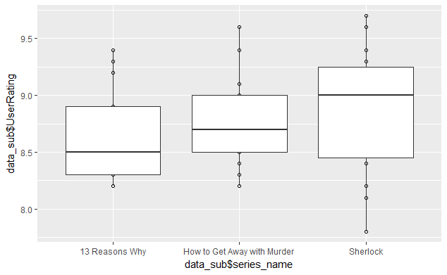

A partir desse gráfico podemos ver que a mediana do boxplot de **Sherlok** está acima das outras mas o bloxplot dele é o que apresenta maior espalhamento dos dados,já o de **How to Get Away with Murder** parece ser mais preciso e com notas mais constantes e proximas umas das outras, ou seja, **Sherlok** é o que possui notas mais irregulares dos 3 casos. Para afirmar que **Sherlok** é a série que mais possui episodios irregulares com mais certeza, podemos utilizar o desvio padrão, que é o quão disperso os dados estão em torno da média, de cada uma das séries e comparalos.

```r
sd(filter(data_sub, series_name == "Sherlock")$UserRating)
```

```
[1] 0.5665266
```

```r
sd(filter(data_sub, series_name == "13 Reasons Why")$UserRating)
```

```
[1] 0.4130872
```

```r
sd(filter(data_sub, series_name == "How to Get Away with Murder")$UserRating)
```

```
[1] 0.3520216
```

Podemos ver que **Sherlok** possui a maior dipersão dentre as 3 séries selecionadas.

# Checkpoint 4

# As series que tiveram uma queda de desempenho após uma temporada com alto rating?

A primeira pergunta a se fazer é: *quando uma temporada é considerada com alto rating?* Utilizaremos a mediana da temporada e verificaremos se ela é alta, vamos definir que abaixo de 8.7 seja de baixo rating.

Então vamos agrupar as séries por temporada fazendo a mediana de cada temporada.

```r
tv_shows_resume <- group_by(data_all_shows,series_name,season) %>%
  summarize(eps = n(), median = median(UserRating, na.rm = T))
tv_shows_resume
```

| series_name | season | eps | median |
| --- | --- | --- | --- |
| 13 Reasons Why | 1 | 13 | 8.50 |
| Agents of S.H.I.E.L.D. | 1 | 22 | 8.20 |
| Agents of S.H.I.E.L.D. | 2 | 22 | 8.60 |
| Agents of S.H.I.E.L.D. | 3 | 22 | 8.65 |
| Agents of S.H.I.E.L.D. | 4 | 21 | 8.80 |
| Arrow | 1 | 23 | 8.50 |
| Arrow | 2 | 23 | 8.90 |
| Arrow | 3 | 23 | 8.70 |
| Arrow | 4 | 23 | 8.20 |
| Arrow | 5 | 21 | 8.50 |

[output cut: 137 more lines]

Agora vamos ver a variação de uma temporada para outra para cada série.

```r
tv_shows_resume <- group_by(data_all_shows,series_name,season) %>%
  summarize(eps = n(), median = median(UserRating, na.rm = T)) %>%
  mutate(variation=(median - lag(median)), last_season = lag(median))
tv_shows_resume
```

| series_name | season | eps | median | variation | last_season |
| --- | --- | --- | --- | --- | --- |
| 13 Reasons Why | 1 | 13 | 8.50 | NA | NA |
| Agents of S.H.I.E.L.D. | 1 | 22 | 8.20 | NA | NA |
| Agents of S.H.I.E.L.D. | 2 | 22 | 8.60 | 0.40 | 8.20 |
| Agents of S.H.I.E.L.D. | 3 | 22 | 8.65 | 0.05 | 8.60 |
| Agents of S.H.I.E.L.D. | 4 | 21 | 8.80 | 0.15 | 8.65 |
| Arrow | 1 | 23 | 8.50 | NA | NA |
| Arrow | 2 | 23 | 8.90 | 0.40 | 8.50 |
| Arrow | 3 | 23 | 8.70 | -0.20 | 8.90 |
| Arrow | 4 | 23 | 8.20 | -0.50 | 8.70 |
| Arrow | 5 | 21 | 8.50 | 0.30 | 8.20 |

[output cut: 137 more lines]

Assim podemos, por fim filtrar, os dados para terem apenas as series que tinham alto rating depois cairam.

```r
tv_shows_resume <- group_by(data_all_shows,series_name,season) %>%
  summarize(eps = n(), median = median(UserRating, na.rm = T)) %>%
  mutate(variation=(median - lag(median)), last_season = lag(median)) %>%
  filter(variation < 0, last_season >= 8.7, median < 8.7)
tv_shows_resume
```

| series_name | season | eps | median | variation | last_season |
| --- | --- | --- | --- | --- | --- |
| Arrow | 4 | 23 | 8.20 | -0.50 | 8.70 |
| Dexter | 3 | 12 | 8.60 | -0.25 | 8.85 |
| Dexter | 6 | 12 | 8.40 | -0.50 | 8.90 |
| Dexter | 8 | 12 | 7.95 | -0.90 | 8.85 |
| Flash | 3 | 22 | 8.55 | -0.35 | 8.90 |
| House of Cards | 3 | 13 | 8.50 | -0.20 | 8.70 |
| How to Get Away with Murder | 3 | 15 | 8.60 | -0.20 | 8.80 |
| Once Upon a Time | 4 | 24 | 8.50 | -0.20 | 8.70 |
| Prison Break | 3 | 13 | 8.50 | -0.20 | 8.70 |
| Sherlock | 4 | 4 | 8.30 | -0.75 | 9.05 |

Essas são as séries e as temporadas em que houve uma baixa na qualidade e o rating diminuiu.  
Isso levanta outra pergunta:*Qual série teve a maior queda no rating?*

```r
min(tv_shows_resume$variation)
```

```
[1] -0.9
```

A maior queda foi de -0.9 que foi na 8 temporada de **Dexter**

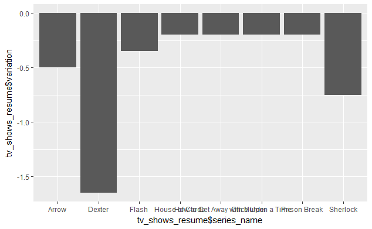

# Series com poucos episódios são melhores avaliadas que as com maior numero de episódios?

Para isso temos que dividir as séries em dois grupos,o com muitos episodios e o com poucos episodios. Vamos definir que uma série que tenho mais de 25 episodios se encaixa no grupo com muitos episodios.

```r
big_shows <- group_by(data_all_shows,series_name) %>%
  summarize(eps = n(), median = median(UserRating, na.rm = T)) %>%
  filter(eps > 25)
big_shows
```

| series_name | eps | median |
| --- | --- | --- |
| Agents of S.H.I.E.L.D. | 87 | 8.60 |
| Arrow | 113 | 8.60 |
| Breaking Bad | 62 | 8.90 |
| Daredevil | 26 | 8.95 |
| Dexter | 96 | 8.70 |
| Flash | 68 | 8.70 |
| Friends | 236 | 8.50 |
| Game of Thrones | 60 | 8.95 |
| Gotham | 62 | 8.40 |
| Greyâ€™s Anatomy | 291 | 8.20 |

[output cut: 14 more lines]

```r
small_shows <- group_by(data_all_shows,series_name) %>%
  summarize(eps = n(), median = median(UserRating, na.rm = T)) %>%
  filter(eps <= 25)
small_shows
```

| series_name | eps | median |
| --- | --- | --- |
| 13 Reasons Why | 13 | 8.50 |
| Black Mirror | 13 | 8.30 |
| Mr Robot | 22 | 8.80 |
| Narcos | 20 | 8.70 |
| Sense8 | 23 | 9.00 |
| Sherlock | 15 | 9.00 |
| Stranger Things | 8 | 8.95 |

Podemos comparar as medianas dos dois grupos para vermos qual se dará melhor.

```r
median(big_shows$median)
```

```
[1] 8.5
```

```r
median(small_shows$median)
```

```
[1] 8.8
```

Então sim, séries com menos de 25 episódios são melhores avaliadas que as que possuem mais.  
Gerando outra pergunta:**Mas qual a variancia desses dados e qual está mais espalhado?**  
Podemos tentar ver isso através de um gráfico boxplot

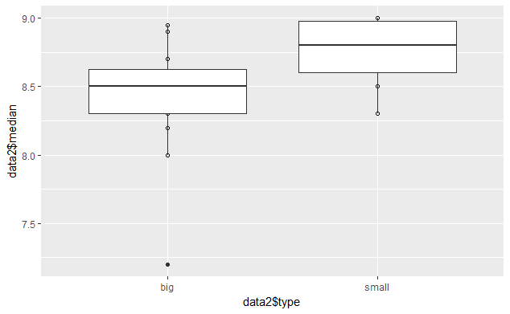

Aparentemente amabas as categorias tem o mesmo espalhamento.Podemos ver isso numericamente também.

```r
sd(big_shows$median)
```

```
[1] 0.360046
```

```r
sd(small_shows$median)
```

```
[1] 0.2692582
```

Numericamente as séries maiores possuem maior espalhamento, o que esperado já que são mais temporadas e mais episódios.

Então podemos concluir que séries com menor numero de episódios levam vantagem contra as grandes séries, também vimos quais séries tiveram quedas após uma boa temporada.